# Latinx Education Attainment and Enrollment Rates (2012-2020) Using the American Community Survey (ACS)

Paula Nazario, Monica Salinas Policy Fellow at the Latino Policy & Politics Institute (LPPI)

June 23, 2022

## ACKNOWLEDGEMENTS

I would like to thank Professor Ozan Jaquette and Crystal Han for their support and assistance for making this research project/product possible.

## RESEARCH QUESTIONS

1. How has the educational attainment rates for Latinx students changed in the past 8 years (e.g., 2012-2020) in areas that are highly populated by Latinx communities?
   1. How has the educational attainment for Latinx students changed in the past 8 years (e.g., 2012-2020) at the state level?
2. How has the educational enrollment rates for Latinx students changed in the past 8 years (e.g., 2012-2020) in areas that are highly populated by Latinx communities?
   1. How has the educational enrollment for Latinx students changed in the past 8 years (e.g., 2012-2020) at the state level?

## BACKGROUND: LATINX STUDENT EDUCATIONAL OUTCOMES

Latino students are expected to increase by 25% by 2030 (Excelencia in Education, 2020). Now more than ever, it is important to create policies and programs that increase higher education completion rates of Latino students to put them on the pathway for shared economic prosperity (Excelencia in Education, 2020). A college graduate with a bachelor’s degree is 24% more likely to be employed and earn about $32,000 annually and $1 million higher over a lifetime (Association of Public & Land-Grant Universities, 2020). In 2019, the average median income for recent college graduates with a bachelor’s degree was about $44,000 per year, in comparison to high school graduates who had an average median income earning of about $33,000 per year (Association of Public & Land-Grant Universities, 2020). Those who obtain a bachelor’s degree are more than twice as likely to volunteer, contribute about 3.5 times more money to charity, and 75% vote in presidential elections. College graduates are also less likely to rely on government assistance programs such as medicaid, housing subsidies, nutrition assistance, unemployment benefits, etc (Association of Public & Land-Grant Universities, 2020). Furthermore, college graduates are 3.5 times less likely to be impoverished and about 5 times less likely to be in prison. It is evident that there are many benefits for students to pursue a higher education degree, which means that these opportunities can be even greater for Latino students.

Latino Students & Higher Education Completion Rates:

While pursuing higher education has many positive externalities in our society, Latino students are lagging behind the rest of their peers in terms of college completion rates. According to Excelencia in Education, Latinos need to earn 6.2 million degrees by 2020 in order for the U.S. to be the top ranked in the world for college degree attainment (Excelencia in Education, 2020). In the U.S., 21% of Latino students ages 18 to 34 were enrolled in higher education in comparison to 24% of their white non-Latino peers (Excelencia in Education, 2020). In terms of degree attainment, 24% of Latino adults who were 25 years of age or older earned an associate’s degree or higher, in comparson to 46% of white non-Latino adults (Excelencia in Education, 2020).

California has the largest Latino population and Latinos graduate from 4-year institutions of higher education at higher rates nationally (Excelencia in Education, 2020). Yet, California is behind in the number of Latino students who complete a college education (Excelencia in Education, 2020). About 43% of Latino students are represented in California’s public higher education system, 61% of California’s Latino population lives in Southern California, 40% of Latinos attended college, and 60% of Latinos did not attend college (The Campaign for College Opportunity, 2021). In terms of bachelor degree attainment levels, Latinos have the lowest rates in comparison to other racial/ethnic subgroups in California. Thus, 6% and 14% of Latinos received an associate and bachelor’s degree or higher, respectively, in contrast to 9% and 46% of white students who received an associate and bachelor’s degree or higher, respectively (The Campaign for College Opportunity, 2021).

Even though this data is alarming, there are institutions where Latino students have been able to successfully enroll and graduate from 2 and 4-year institutions. In Fall 2018, Miami Dade College (public, 4-year institution), Florida International University (public, 4-year institution), South Texas College (public, 4-year institution), Lone Star College System (public, 2-year institution), and El Paso Communtiy College (public, 2-year institution) were the top institutions that enrolled the most number of Latino undergraduate students (Excelencia in Education, 2020) (U.S. Department of Education, National Center for Education Statistics (NCES), Integrated Postsecondary Education Data System (IPEDS), 2018 Fall Enrollment, Graduation Rates Survey and Institutional Characteristics Survey.). In terms of the most associate degrees awarded to Latino students, Miami Dade College awarded 6,670 degrees, followed by South Texas College (3,923), El Paso Community College (2,975), Lone Star College System (2,654), and Valencia College (2,574) (Excelencia in Education, 2020). Furthermore, in terms of bachelor degrees awarded to Latino students, the top five institutions included Florida International University (6,764), California State University, Fullerton (3,660), The University of Texas Rio Grande Valley (3,618), California State University, Northridge (3,573), and California State University, Long Beach (3,417) (Excelencia in Education, 2020). Although these institutions have done great work in ensuring that more Latino students are enrolling and completing their associate and bachelor degrees, we still have a long way to go to ensure that Latino students across the U.S. feel supported to continue their education.

## LATINX EDUCATION ATTAINMENT BY GENDER (2012-2020)

### ACS1 - Latinx Education Attainment Rates in California, Texas, Florida, and New York States (2012-2020)

I used the ACS 1-year and ACS 5-year level data to determine the educational attainment rates of Latinx students between 2012 and 2020 in the following states: California, Texas, Florida, and New York. All of these states have seen an increase in the Latinx population since 2010. Therefore, I want to generate line graphs of the educational attainment rates of Latinx students in each state individually and then compare them against each other to analyze any patterns in the educational rates of each state.

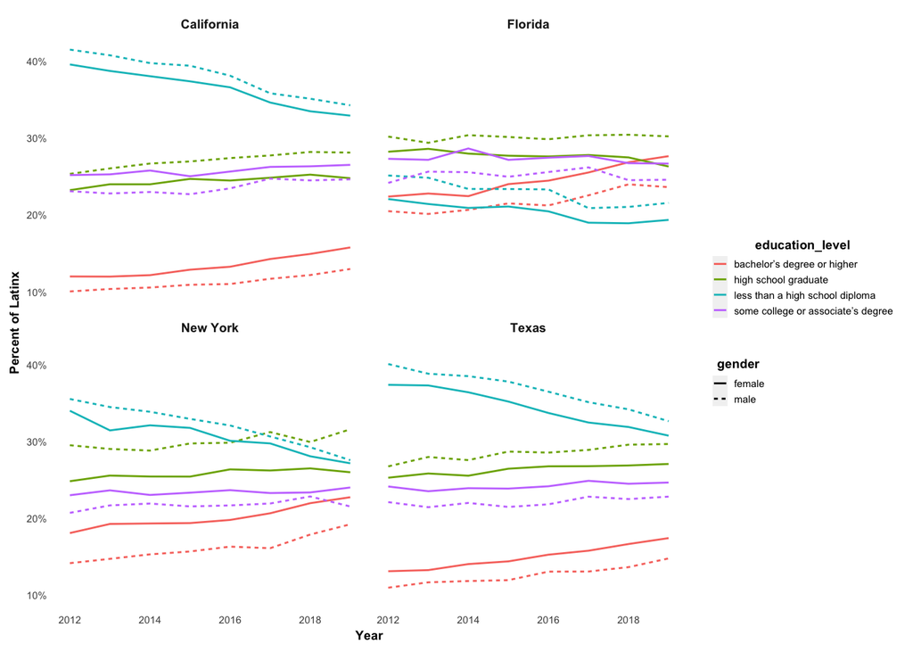

Figure 1: ACS 1-Year Level Data: Latinx Education Attainment Rates in California, Texas, Florida, and New York States (2012-2020)

In Figure 1, we can see the Latinx Education Attainment Rates for California, Florida, New York, and Texas between 2012-2020. In these graphs we can see that among the four states, there is a higher percentage of Latinx students obtaining bachelor’s degrees or higher in Florida, followed by New York, Texas and California and in all states more Latina women are obtaining these degrees. Among the four states, California has the most Latinx students obtaining less than high school diplomas, with a higher percentage of Latino males obtaining these diplomas.

### ACS5 - Latinx Education Attainment Rates in California, Texas, Florida, and New York States (2012-2020)

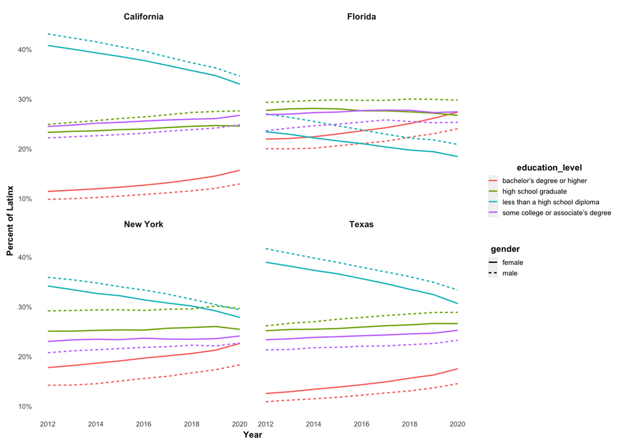

Figure 2: ACS 5-Year Level Data: Latinx Education Attainment Rates in California, Texas, Florida and New York States (2012-2020)

## LATINX ENROLLNMENT IN NURSERY SCHOOL, K-12, COLLEGE/UNIVERSITIES, AND GRADUATE OR PROFESSIONAL SCHOOL (2012-2020)

### ACS1 - Latinx Enrollment Rates in Nursery, K-12, College/Universities, and Graduate or Professional School in California, Texas, Florida, and New York States (2012-2020)

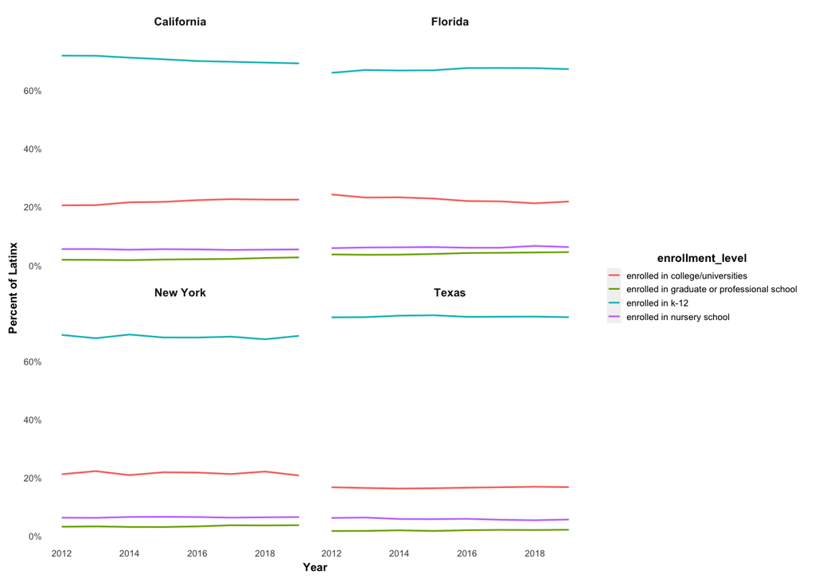

Figure 3: ACS 1-Year Level Data: Latinx Enrollment Rates in Nursery, K-12, College/Universities, and Graduate or Professional School in California, Texas, Florida, and New York States (2012-2020)

In Figure 3, we can see that there are a larger percent of Latinx students enrolled in K-12 school across California, Texas, Florida, and New York. On the other hand, these graphs also indicate that there are very few Latinx students enrolled in nursery school and graduate or professional school in California, Texas, Florida, and New York.

### ACS5 - Latinx Enrollment Rates in Nursery, K-12, College/Universities, and Graduate or Professional School in California, Texas, Florida, and New York States (2012-2020)

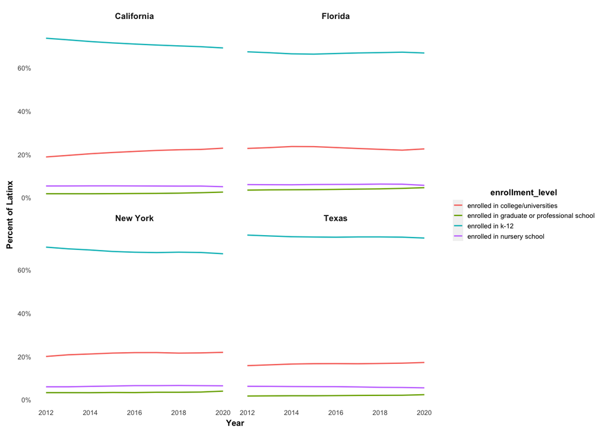

Figure 4: ACS 5-Year Level Data: Latinx Enrollment Rates in Nursery, K-12, College/Universities, and Graduate or Professional School in California, Texas, Florida, and New York States (2012-2020)

In Figure 4, we can see the Latinx enrollment rates in nursery school, K-12, college/universities, and graduate or professional school in California, Texas, Florida, and New York.

## ENROLLMENT RATES IN NURSERY SCHOOL BY RACE/ETHNICITY (2012-2020)

### ACS1 - Education Enrollment Rates in California, Texas, Florida, and New York States (2012-2020)

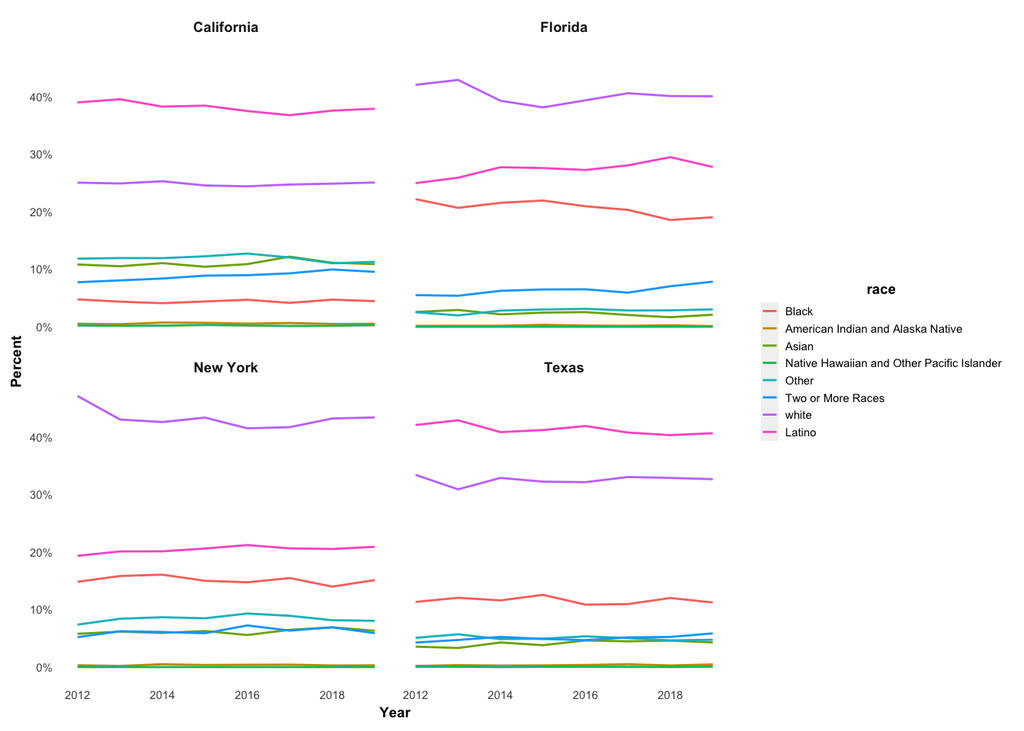

Figure 5: ACS 1-Year Level Data: Nursery School Enrollment Rates in California, Texas, Florida, and New York States (2012-2020)

## ENROLLMENT RATES IN K-12 BY RACE/ETHNICITY (2012-2020)

### ACS1 - Education Enrollment Rates in California, Texas, Florida, and New York States (2012-2020)

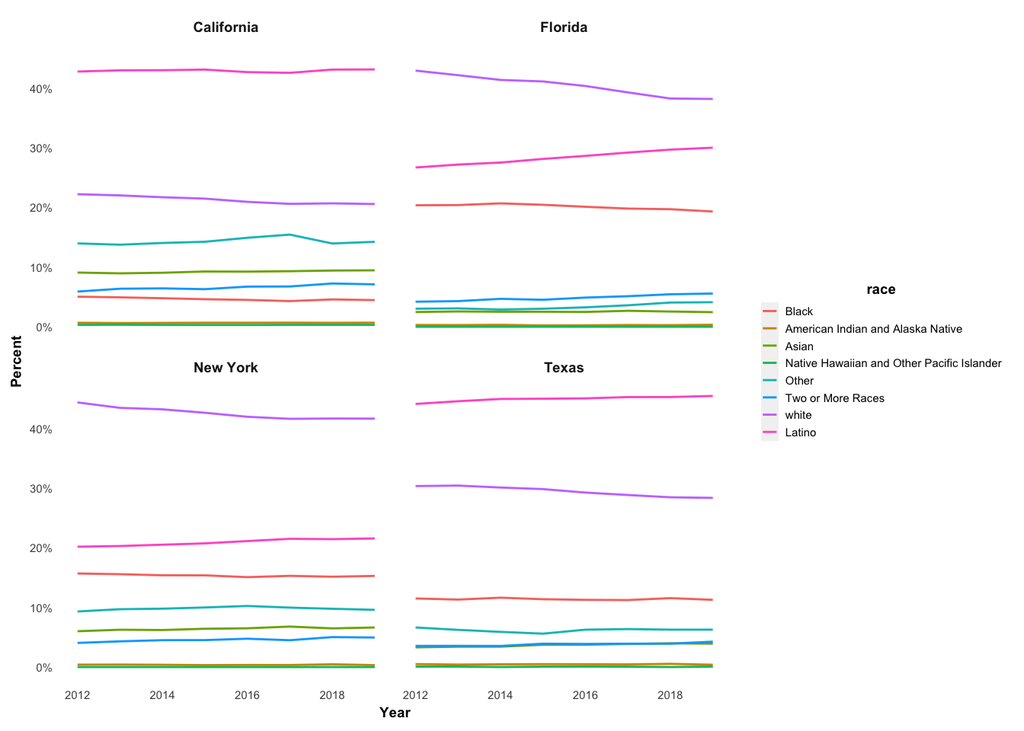

Figure 6: ACS 1-Year Level Data: K-12 School Enrollment Rates By Race/Ethnicity in California, Texas, Florida, and New York States (2012-2020)

## ENROLLMENT RATES IN COLLEGE/UNIVERSITIES BY RACE/ETHNICITY (2012-2020)

### ACS1 - Education Enrollment Rates in California, Texas, Florida, and New York States (2012-2020)

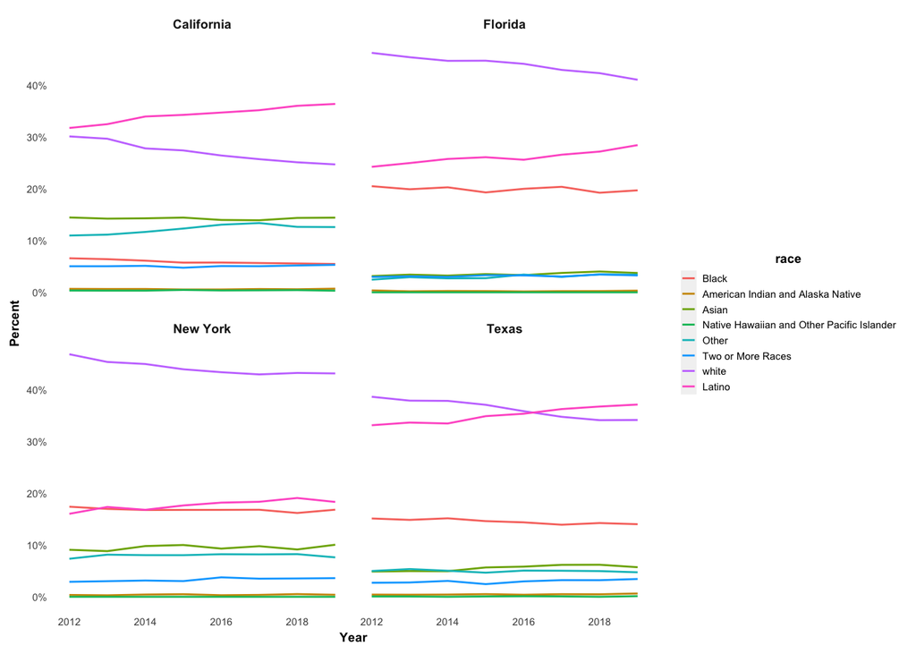

Figure 7: ACS 1-Year Level Data: College/University Enrollment Rates By Race/Ethnicity in California, Texas, Florida, and New York States (2012-2020)

## ENROLLMENT RATES IN GRADUATE OR PROFESSIONAL SCHOOL BY RACE/ETHNICITY (2012-2020)

### ACS1 - Education Enrollment Rates in California, Texas, Florida, and New York States (2012-2020)

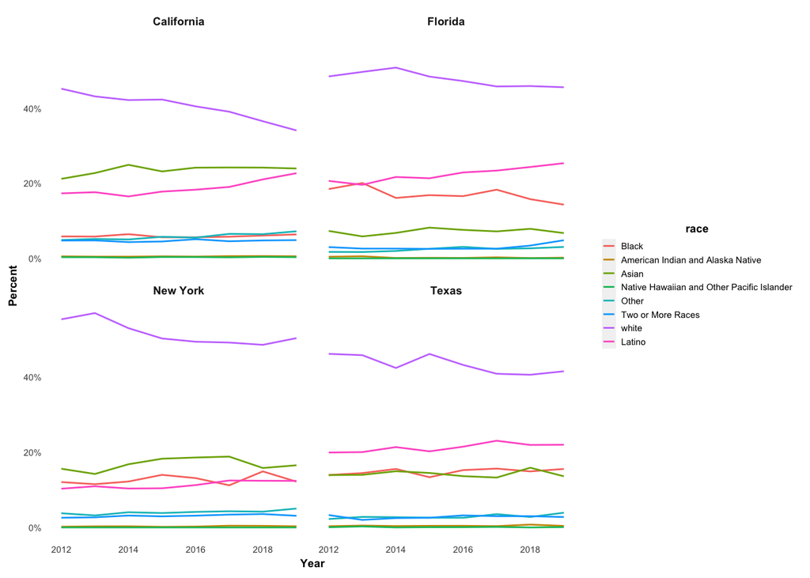

Figure 8: ACS 1-Year Level Data: Graduate or Professional School Enrollment Rates By Race/Ethnicity in California, Texas, Florida, and New York States (2012-2020)

## COMPARISON GROUPS: COLLEGE/UNIVERSITY ENROLLMENT RATES BY RACE/ETHNICITY IN CALIFORNIA, TEXAS, FLORIDA, AND NEW YORK (2012-2020)

### ACS5 - Education Enrollment Rates in California, Texas, Florida, and New York States (2012-2020)

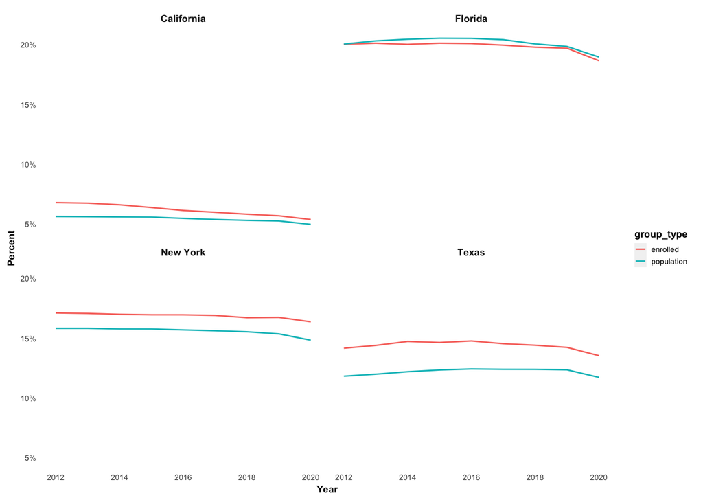

Figure 9: ACS 5-Year Level Data: College/University Enrollment Rates of Black Students in California, Texas, Florida, and New York States (2012-2020)

In Figure 9, the graphs depict the college/university enrollment rates of Black students (ages 18 to 24) in comparison to the Black population in California, Texas, Florida, and New York States. Overall, it seems like there is a higher percent of Black students enrolled in college/university in comparison to the Black population in California, New York, and Texas.

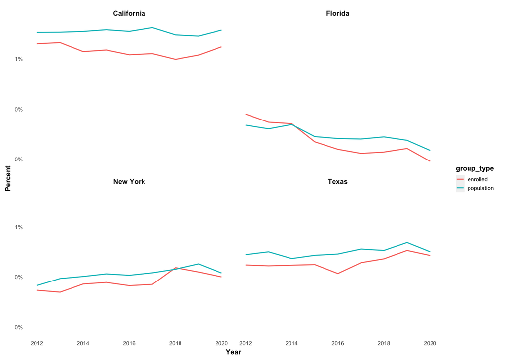

Figure 10: ACS 5-Year Level Data: College/University Enrollment Rates of American Indian and Alaska Native Students in California, Texas, Florida, and New York States (2012-2020)

In Figure 10, the graphs depict the college/university enrollment rates of American Indian and Alaska Native students (ages 18 to 24) in comparison to the American Indian and Alaska Native population in California, Texas, Florida, and New York States. Overall, it seems like there are less American Indian and Alaska Native students enrolled in college/university in comparison to the American Indian and Alaska Native population in California, Florida, New York, and Texas.

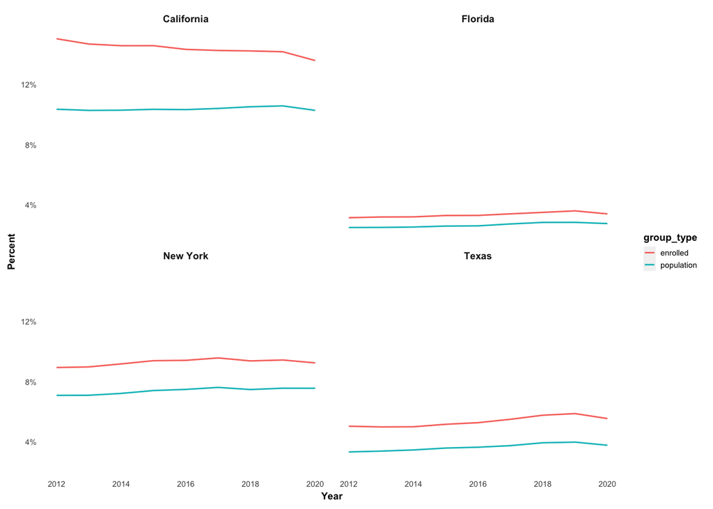

Figure 11: ACS 5-Year Level Data: College/University Enrollment Rates of Asian Students in California, Texas, Florida, and New York States (2012-2020)

In Figure 11, the graphs depict the college/university enrollment rates of Asian students (ages 18 to 24) in comparison to the Asian population in California, Texas, Florida, and New York States. In California and New York, there are more Asian students enrolled in college/university in comparison to the Asian population in those states. In Florida and Texas, there is also a higher percent of Asian students enrolled in college/university in in comparison to the Asian population. However, there is a lower percentage of Asian students enrolled in college/university in Florida and Texas in comparison to the Asian students enrolled in California and New York.

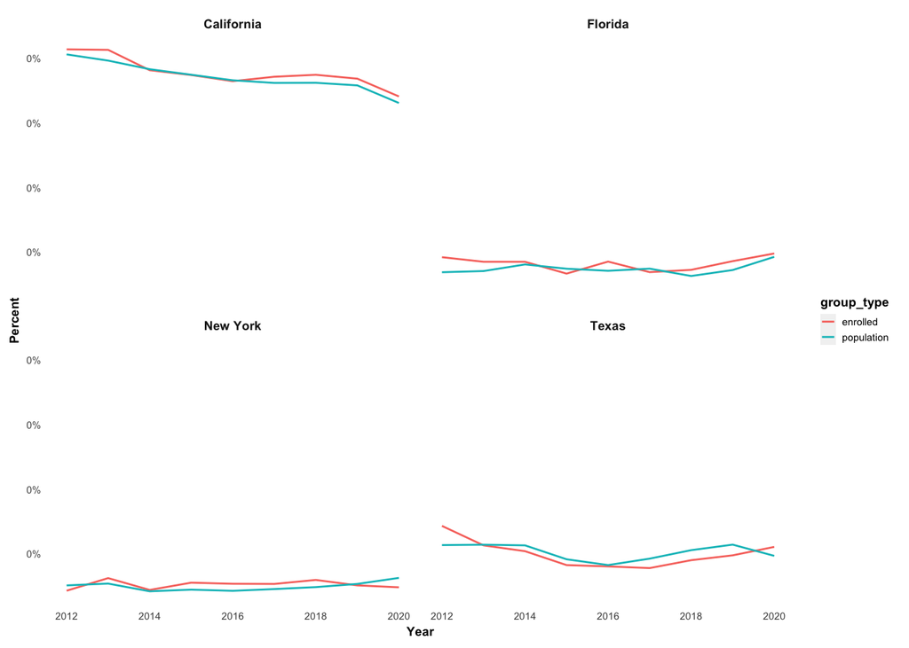

Figure 12: ACS 5-Year Level Data: College/University Enrollment Rates of Native Hawaiian and Other Pacific Islander Students in California, Texas, Florida, and New York States (2012-2020)

In Figure 12, the graphs depict the college/university enrollment rates of Native Hawaiian and Other Pacific Islander students (ages 18 to 24) in comparison to the Native Hawaiian and Other Pacific Islander population in California, Texas, Florida, and New York States. Overall, it seems like there is not enough information/data on this population group, which means that these graphs may not portray an accurate representation of the number of Native Hawaiian and Other Pacific Islander students enrolled in college/university.

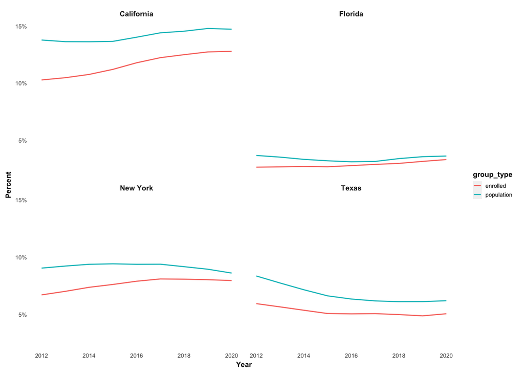

Figure 13: ACS 5-Year Level Data: College/University Enrollment Rates of Students who were of Other Races in California, Texas, Florida, and New York States (2012-2020)

In Figure 13, the graphs depict the college/university enrollment rates of students who were of other races (ages 18 to 24) in comparison to the population of students who were of other races in California, Texas, Florida, and New York States. In California, there seems to be an upward trend in the percent of students enrolled in college/university, which is proportionate to the increase in size of the population group. On the other hand, the percent of students enrolled in college/university in New York, Florida, and Texas is lower in comparison to its population size and California.

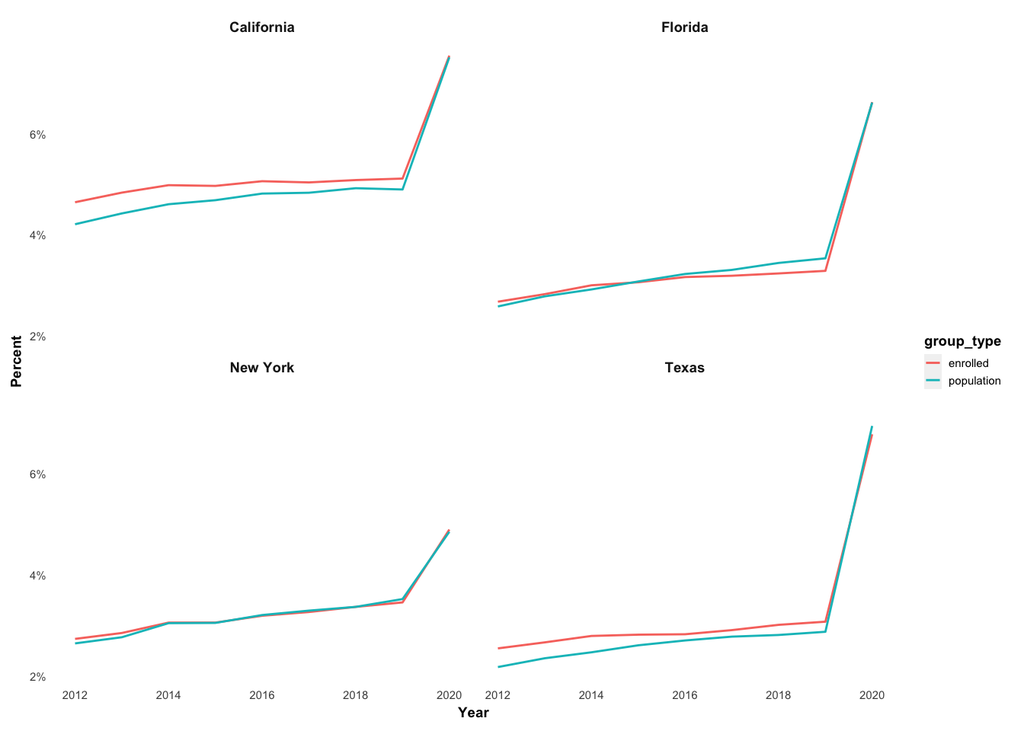

Figure 14: ACS 5-Year Level Data: College/University Enrollment Rates of Students who were of Two or More Races in California, Texas, Florida, and New York States (2012-2020)

In Figure 14, the graphs depict the college/university enrollment rates of students who were of two or more races (ages 18 to 24) in comparison to the population of students who were of two or more races in California, Texas, Florida, and New York States.

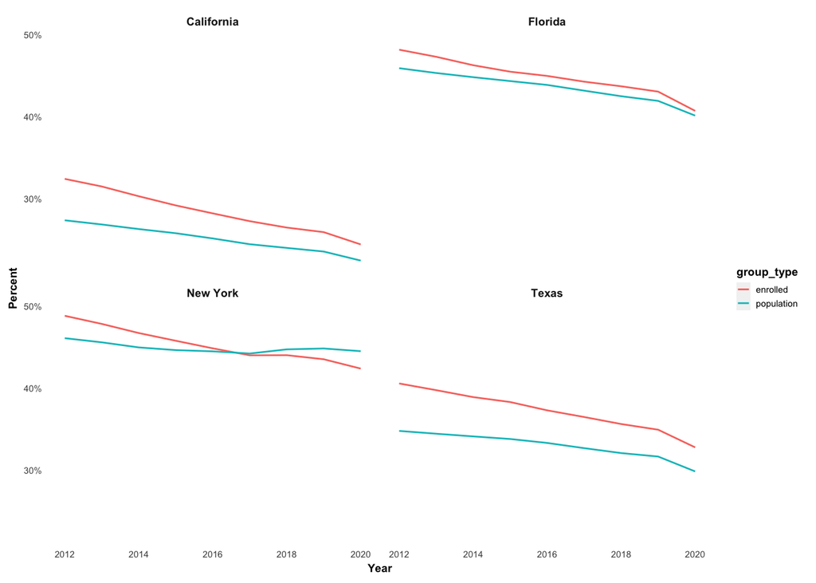

Figure 15: ACS 5-Year Level Data: College/University Enrollment Rates of White Students in California, Texas, Florida, and New York States (2012-2020)

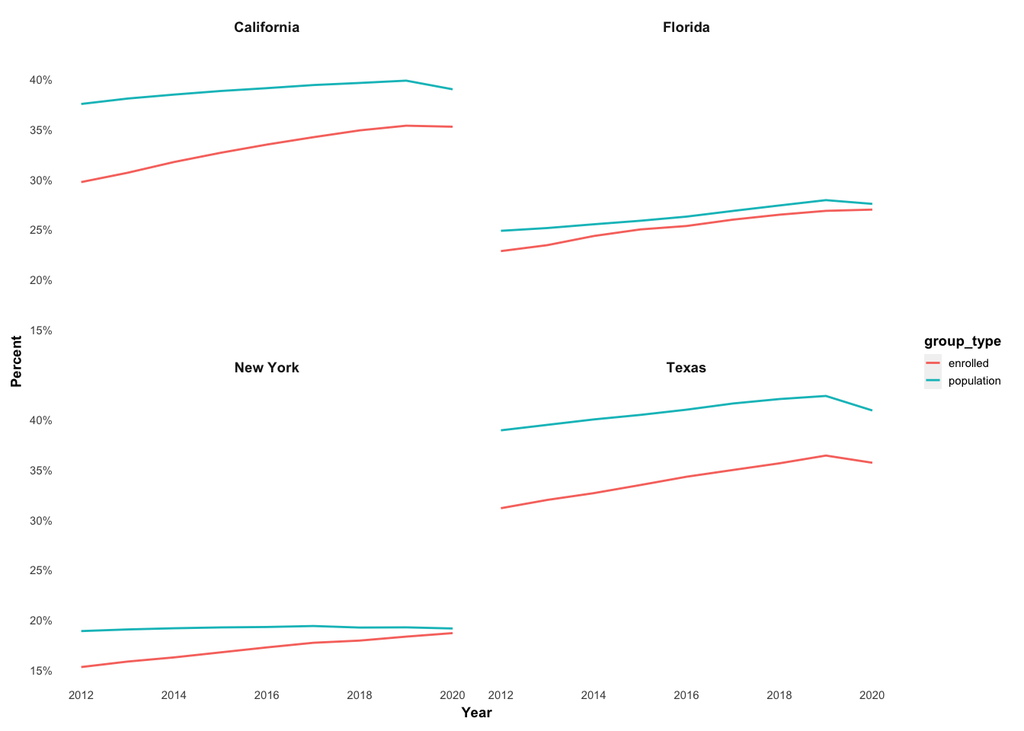

Figure 16: ACS 5-Year Level Data: College/University Enrollment Rates of Latinx Students in California, Texas, Florida, and New York States (2012-2020)

In Figure 16, the graphs depict the college/university enrollment rates of Latinx students (ages 18 to 24) in comparison to the Latinx population in California, Texas, Florida, and New York States. Overall, it seems like there is an upward trend in the percent of Latinx students enrolled in college/university and the percent of Latinx students enrolled in college/university is lower than the Latinx population in California, New York, Florida, and Texas.

## COMPARISON GROUPS: GRADUATE OR PROFESSIONAL SCHOOL ENROLLMENT RATES BY RACE/ETHNICITY IN CALIFORNIA, TEXAS, FLORIDA, AND NEW YORK (2012-2020)

### ACS5 - Education Enrollment Rates in California, Texas, Florida, and New York States (2012-2020)

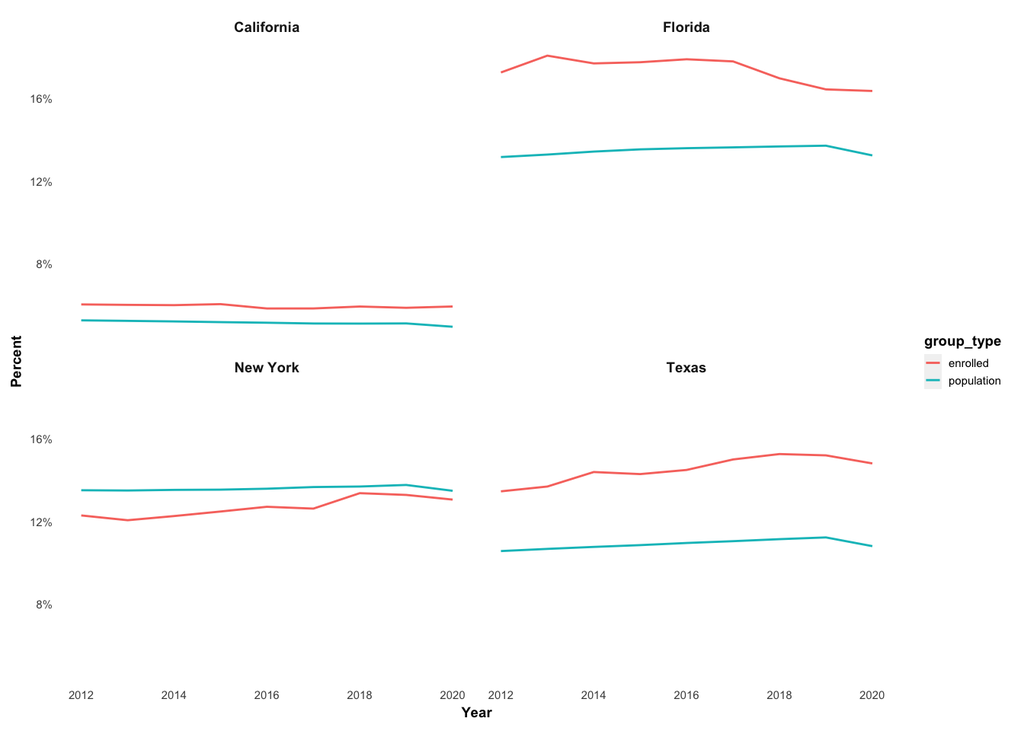

Figure 17: ACS 5-Year Level Data: Graduate or Professional School Enrollment Rates of Black Students in California, Texas, Florida, and New York States (2012-2020)

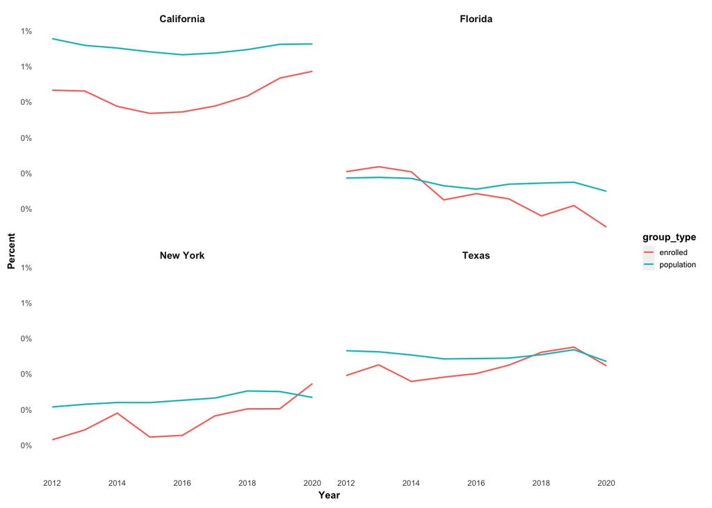

Figure 18: ACS 5-Year Level Data: Graduate or Professional School Enrollment Rates of American Indian and Alaska Native Students in California, Texas, Florida, and New York States (2012-2020)

In Figure 18, the graphs depict the graduate or professional school enrollment rates of American Indian and Alaska Native students (ages 18 to 24) in comparison to the American Indian and Alaska Native population in California, Texas, Florida, and New York. Overall, it seems like there is a low percentage of American Indian and Alaska Native students enrolled in graduate or professional school in comparison to the Alaska Native population in California, Texas, Florida, and New York.

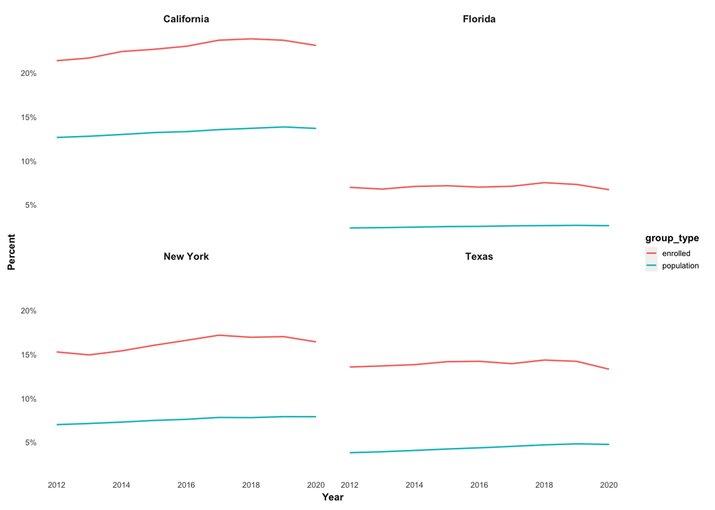

Figure 19: ACS 5-Year Level Data: Graduate or Professional School Enrollment Rates of Asian Students in California, Texas, Florida, and New York States (2012-2020)

In Figure 19, the graphs depict the graduate or professional school enrollment rates of Asian students (ages 18 to 24) in comparison to the Asian population in California, Texas, Florida, and New York. In all the states, it seems like there is a higher percent of Asian students enrolled in graduate or professional school in comparison to the Asian population, but there is a higher enrollment in graduate or professional school in California.

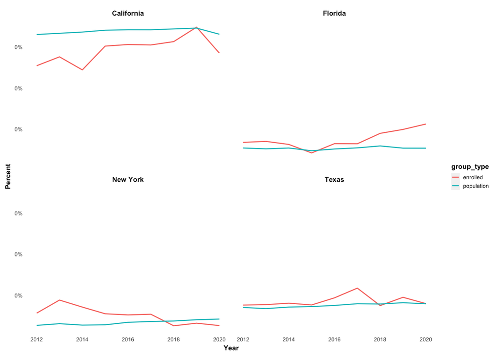

Figure 20: ACS 5-Year Level Data: Graduate or Professional School Enrollment Rates of Native Hawaiian and Other Pacific Islander Students in California, Texas, Florida, and New York States (2012-2020)

In Figure 20, the graphs depict the graduate or professional school enrollment rates of Native Hawaiian and Other Pacific Islander students (ages 18 to 24) in comparison to the Native Hawaiian and Other Pacific Islander population in California, Texas, Florida, and New York.

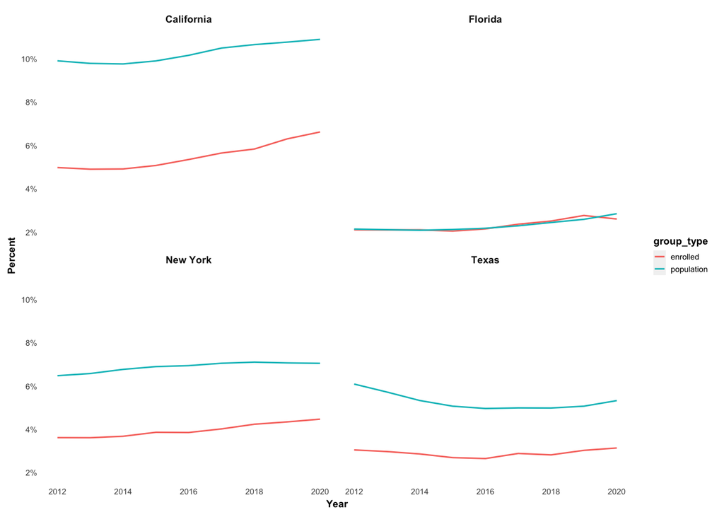

Figure 21: ACS 5-Year Level Data: Graduate or Professional School Enrollment Rates of Students who were of Other Races in California, Texas, Florida, and New York States (2012-2020)

In Figure 21, the graphs depict the graduate or professional school enrollment rates of students who are of other races (ages 18 to 24) in comparison to the population of students who are of other races in California, Texas, Florida, and New York. In Florida, it seems like the number of students enrolled and the population of students who are of other races were almost the same.

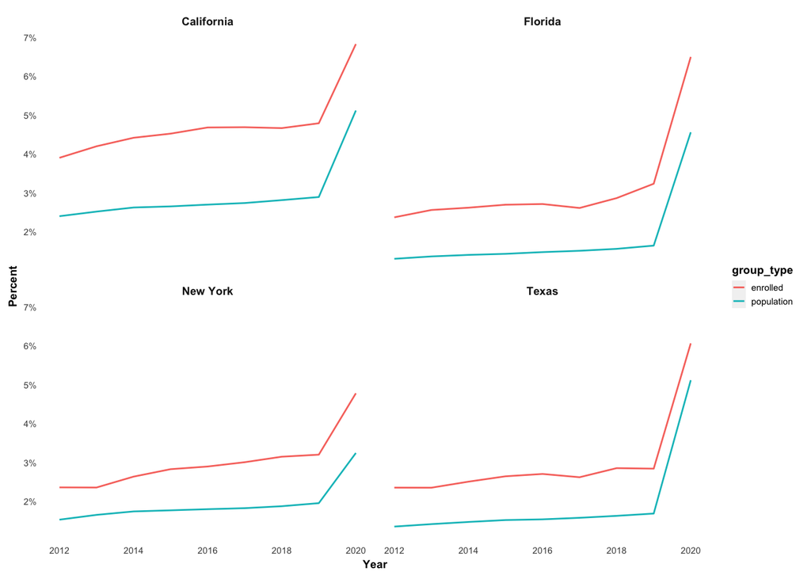

Figure 22: ACS 5-Year Level Data: Graduate or Professional School Enrollment Rates of Students who were of Two or More Races in California, Texas, Florida, and New York States (2012-2020)

In Figure 22, the graphs depict the graduate or professional school enrollment rates of students who were of two or more races (ages 18 to 24) in comparison to the population of students who were of two or more races in California, Texas, Florida, and New York.

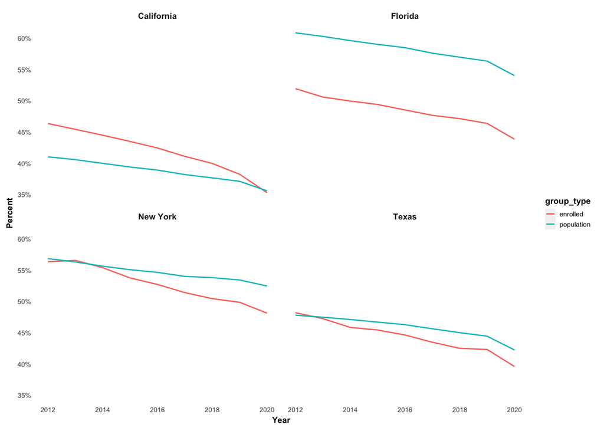

Figure 23: ACS 5-Year Level Data: Graduate or Professional School Enrollment Rates of White Students in California, Texas, Florida, and New York States (2012-2020)

In Figure 23, the graphs depict the graduate or professional school enrollment rates of white students (ages 18 to 24) in comparison to the population of white students in California, Texas, Florida, and New York. In Florida, there is a low percent of white students who are enrolled in graduate or professional school in comparison to the white population in California, Texas, Florida, and New York.

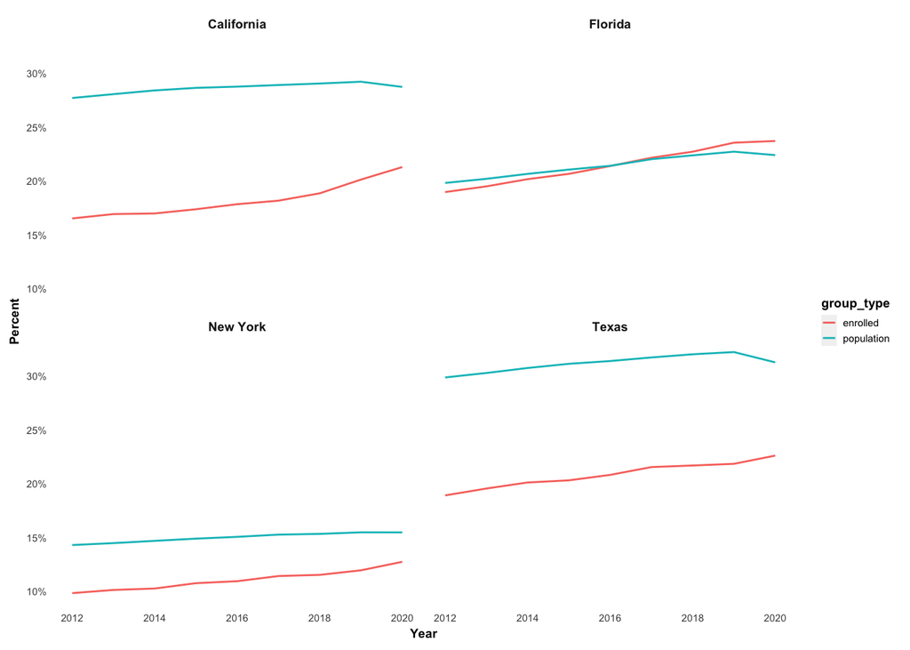

Figure 24: ACS 5-Year Level Data: Graduate or Professional School Enrollment Rates of Latinx Students in California, Texas, Florida, and New York States (2012-2020)

In Figure 24, the graphs depict the graduate or professional school enrollment rates of Latinx students (ages 18 to 24) in comparison to the population of Latinx students in California, Texas, Florida, and New York. In California, there is a low percent of Latinx students who are enrolled in graduate or professional school in comparison to the percent of Latinx students; there is also a large gap between the percent of Latinx students enrolled in graduate or professional school and the Latinx population.

## REFERENCES

Association of Public & Land-Grant Universities. (2020). How do college graduates benefit society at large? https://www.aplu.org/our-work/5-archived-projects/college-costs-tuition-and-financial-aid/publicuvalues/societal-benefits.html.

Excelencia in Education. (2020). Latino college completion: United states. https://www.edexcelencia.org/sites/default/files/LCCStateStats/Exc-2020-50StateFS-USA-05.pdf.

Richard Fry. (2021). First-generation college graduates lag behind their peers on key economic outcomes. https://www.pewresearch.org/social-trends/2021/05/18/first-generation-college-graduates-lag-behind-their-peers-on-key-economic-outcomes/.

The Campaign for College Opportunity. (2021). The state of higher education for latinx californians. https://collegecampaign.org/portfolio/2021-state-higher-education-latinx-californias/.